# Example Script

2022 K-SAS Sports Analytics Competition

S Kim

## Load Data and Libraries

We first loaded the data and the libraries that we would need for the analysis. The data were provided by the competition organizers, and it represents 943 skaters in the 2021-2022 NHL. We also loaded the `mosaic` and `dplyr` packages.

```r
skaters <- readRDS(url('https://github.com/kim3-sudo/nhlskaters/blob/main/data/skaters.rds?raw=true'))
```

```r
library(mosaic)
library(dplyr)
```

## Clean/Prep Data

We want to clean our data before we analyze it, there are some weird observations that we don’t want affecting our results. We can clean this data using the R code shown.

```r
skaters <- subset(skaters, playerid != 'nashri02')
skaters <- subset(skaters, playerid != 'wolanch01')
skaters <- subset(skaters, playerid != 'brookad01')
```

```r
mean(skaters$goals)
```

```
## [1] 4.78617
```

```r
median(skaters$goals)
```

```
## [1] 3
```

```r
skaters$morethanfour <- ifelse(skaters$goals >= 4, TRUE, FALSE)
```

## Exploratory Data Analysis

In order to get a view of the data, we made some boxplots and looked at the summary statistics of the variables that we were interested in.

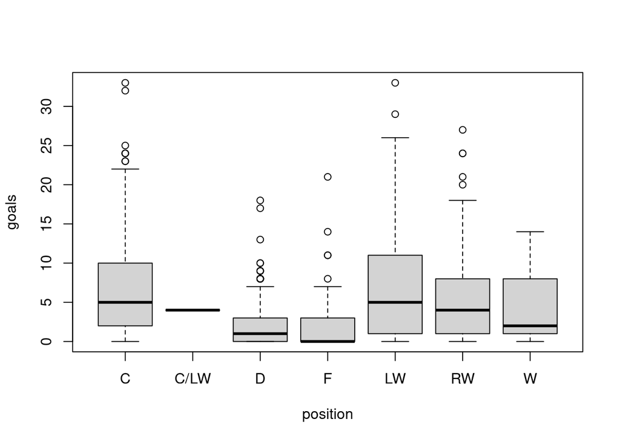

```r
boxplot(goals ~ position, data = skaters)
```

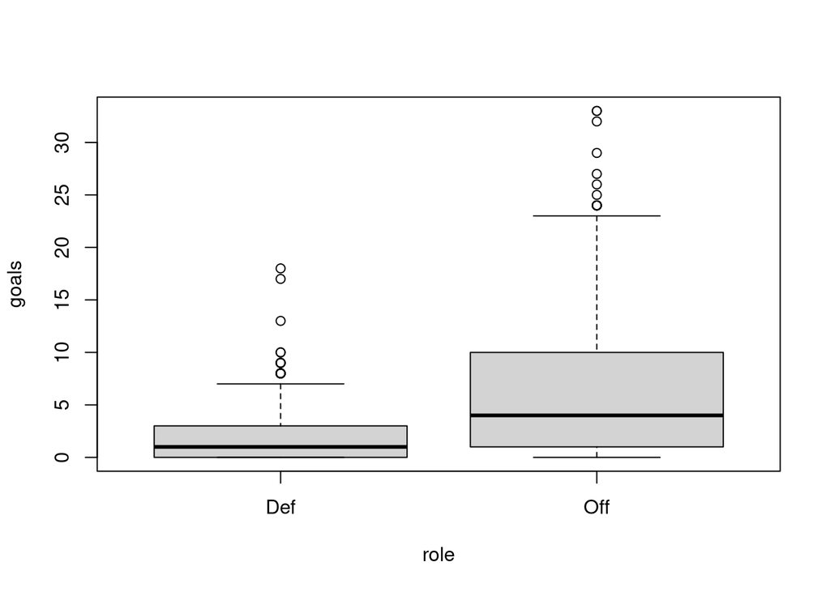

```r
boxplot(goals ~ role, data = skaters)
```

```r
favstats(goals ~ position, data = skaters)
```

```
##   position min Q1 median Q3 max     mean       sd   n missing
## 1        C   0  2      5 10  33 6.592593 6.333551 297       0
## 2     C/LW   4  4      4  4   4 4.000000       NA   1       0
## 3        D   0  0      1  3  18 2.079755 2.702663 326       0
## 4        F   0  0      0  3  21 2.729730 4.764735  37       0
## 5       LW   0  1      5 11  33 6.953642 7.154800 151       0
## 6       RW   0  1      4  8  27 5.536000 5.939947 125       0
## 7        W   0  1      2  8  14 5.333333 7.571878   3       0
```

```r
favstats(goals ~ role, data = skaters)
```

```
##   role min Q1 median   Q3 max     mean       sd   n missing
## 1  Def   0  0      1 3.00  18 2.079755 2.702663 326       0
## 2  Off   0  1      4 9.75  33 6.223127 6.449507 614       0
```

We also got tallies for the proportions, which we will use in our $Z$-test.

```r
tally(filter(skaters, role == "Def")$morethanfour)
```

```
## X
##  TRUE FALSE
##    69   257
```

```r
tally(filter(skaters, role == "Off")$morethanfour)
```

```
## X
##  TRUE FALSE
##   341   273
```

```r
tally(skaters$role)
```

```
## X
## Def Off
## 326 614
```

## Conditions

The conditions for the $Z$-test call for a large sample size, independence, normality, and randomization. Our sample size after trimming down the bad observations is 940, which we consider to be good, so this condition is met. For the independence condition, we believe that each player shouldn’t affect each other too much, so this condition is met.

In order to check normality, we made a normal QQ plot.

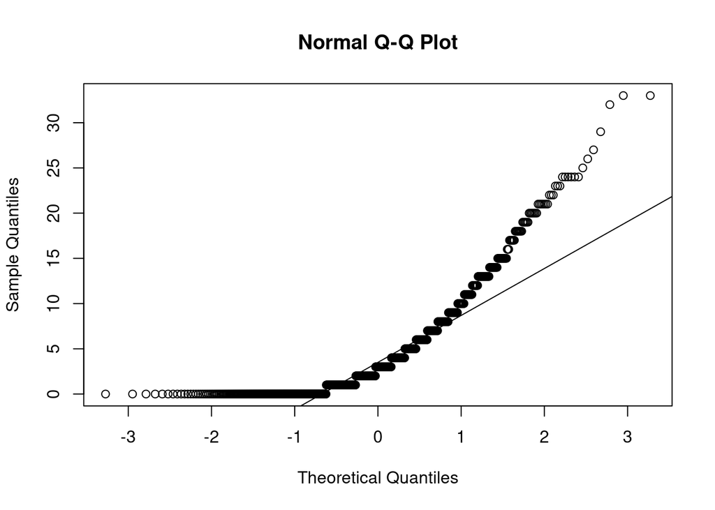

```r
qqnorm(skaters$goals)
qqline(skaters$goals)
```

We find that the data points stray from what normal data should look like, but because our sample size is so large (at 940 observations), we are willing to overlook this.

The only condition that we’re not sure of is the randomization, and whether the randomization condition is met depends on what we want to evaluate. If we want to evaluate whether the conclusions we draw are representative of all ice hockey players in the United States and Canada, then this condition is not met, since our study only looks at the most elite of ice hockey players in the United States and Canada. However, among NHL players, we belive it to be well-representative of the population.

## Z-test

In order to run the $Z$-test, we used the `prop.test()` function in R. We specified the proportions of high scorers from our tallies above as a proportion to the $n$ value, or the number of samples in each group. That is, we have 69 high scorers out of 326 defensive players, and we have 341 high scorers out of 614 offensive players. Since we are running a one-sided $Z$-test, we also had to specify that we were using the equal to or less than alternative hypothesis using the `alternative` argument. Finally, we put the results into a variable called `results` and printed `results`.

```r
results <- prop.test(x = c(69, 341), n = c(326, 614), alternative = "less")
results
```

[output not shown]